# Practise Funtioncal Intactness Index

Patrick Alexander Walkden

16/01/2021

### The functional intactness index rationale

This R markdown is going to go through the steps to calculate a measure of functional intactness using the PREDICTS database and the global bird database, which contain data on the composition of ecological communities across land use types, and on morphological traits and dietary and foraging strategies, respectively. The methodology is an extension of the Biodiversity intactness index (BII) workflow that combines two separate models of abundance and compositional similarity to derive a measure of intactness of a community compared to pristine habitat (Primary minimally used habitat in PREDICTS).

To measure functional intactness, first I will calculate a site level metric of functional diversity, Rao’s Quadratic entropy. Rao’s Q is an abundance weighted measure of functional diversity and is the sum of pairwise functional distances between species within a community. Abundance data is obtained from the PREDICTS database while functional traits are derived from 8 morphometric traits through a two step-PCA resulting in axes fo variation explaining differences in body size, locomotion and forging.

Second, I will calculate a measure of functional similarity as the overlap (Based on Jaccard’s similarity index) of hypervolumes in multidimensional trait space. To capture the effects of land-use compared to pristine habitat, the contrasts will be between sites of primary minimally used habitat and all other land use types. This is not a true measure of functional beta-diversity as it does not include the difference in function due to turnover.

As sites that contain a similar assemblage of species may respond similarly to land use change they cannot be considered as independent, therefore I used phylogenetic generalized linear mixed effects models (more on this later), taking functional diversity as a function of land-use type and intensity as well as other pressures including. Other pressures considered are human population density, road density and UN_subregion.

Generalised linear mixed effects models will be used to model functional similarity as a function of the contrast between sites and related pressures.

The output of these models (hopefully), a measure of functional diversity and a measure of the proportion of function retained in impacted sites compared to a “pristine” baseline, once multiplied together will be the proportion of original function retained.

### Load in the necessary packages

```r
rm(list = ls())
require(tidyverse) ## For data manipulation
require(magrittr) ## for piping
require(SYNCSA) ## For calculating functional diversity metric
require(vegan) ## for performing ordination (PCA/PCoA)
require(gower) ## calculating gower distances
require(raster) ## for loading in rasters of environmental variables and roads
require(geosphere) ## calculating geographic distances
require(ade4)  ### i can't remember right now
require(FD) ## calculating functional diversity metrics
require(hypervolume) ## calculating functional similarity/ diversity metrics
require(betapart) ## for calculating functional similarity and for decomposing functional diversity into turnover and nestedness components
require(foreach)## for parallelising loops
require(doParallel) ## ditto
require(sf)   ### for calculate density of roads
require(rgeos) ## ditto
require(lwgeom) ### ditto
```

## 1.1 Preparing the data: Biodiversity data (PREDICTS)

The first stage is going to be loading in the data and preparing it for use in deriving the metrics of functional diversity and similarity.

My focal group will be birds as they are ecologically diverse and have comprehensive and highly resolved species-level data on functional traits and phylogeny available. The global bird database contains information on 9 morphological traits including dimensions on wing, beak and tarsus, and foraging and dietary information on the proportion of species diet obtained from certain sources including fruit, nectar, insects and vertebrates etc.

```r
### Load in the PREDICTS database

PREDICTS <- readRDS("Datasets/PREDICTS/diversity-2020-10-19-02-32-34.rds")

### Foraging data
Forage <- readRDS("Datasets/GBD/Trophic_Foraging_Niche.rds")

### Jetz_traits
Jetz_Traits <- read.csv("Datasets/GBD/GBD_Jetz_averages_11_Nov_2020.csv")
colnames(Jetz_Traits)[1] <- "Jetz_Name"

### Taxonomy cross-walk as not all species in PREDICTS are in the form of the Jetz tree which is the basis of the trait database (Will be changing to Birdlife)
PREDICTS_Taxonomy <- readRDS("Datasets/PREDICTS/PREDICTS_AVES_Updated_Taxonomy.rds")
```

Subset the database to just the birds and while we are practising the workflow I will be looking at records from the Americas. Combine the datasets.

```r
PREDICTS_Aves_Am <- PREDICTS %>% filter(Rank == "Species", Class == "Aves") %>% left_join(PREDICTS_Taxonomy[,c("Taxon", "Jetz_Name")], by = "Taxon") %>%
  left_join(Forage[,c(34:46)], by = c("Jetz_Name" = "Taxon")) %>%
  left_join(Jetz_Traits[,c(1,8:18)], by = "Jetz_Name") %>%
  filter(UN_region == "Americas")
```

Lets take a look what land-use types and intensities the sites that bird communities were sampled in.

```r
table( PREDICTS_Aves_Am$Predominant_habitat, PREDICTS_Aves_Am$Use_intensity)
```

```
##
##                                            Minimal use Light use Intense use
##   Primary forest                                 21908      7196        1609
##   Primary non-forest                              7389      4597        1026
##   Young secondary vegetation                      6306       278           0
##   Intermediate secondary vegetation              12466      3301         145
##   Mature secondary vegetation                     1048       140           0
##   Secondary vegetation (indeterminate age)           0      1368           0
##   Plantation forest                               3633       942         684
##   Pasture                                         1889      1583        1550
##   Cropland                                        6864      4160           0
##   Urban                                           7070      3776           0
##   Cannot decide                                      0         0           0
##
##                                            Cannot decide
##   Primary forest                                    5232
##   Primary non-forest                                   0
##   Young secondary vegetation                        1328
##   Intermediate secondary vegetation                  768
##   Mature secondary vegetation                          0
##   Secondary vegetation (indeterminate age)           178
##   Plantation forest                                 2790
##   Pasture                                          22745
##   Cropland                                         23881
##   Urban                                              101
##   Cannot decide                                        0
```

So looking at this it would be good to collapse both primary and secondary land-use types each into a single land-use category of primary and secondary vegetation, respectively, Additionally, we are going to remove the sites that could not be classified a land-use type or intensity as it’s the effects of these on biodiversity that we are interested in.

```r
PREDICTS_Aves_Am <- PREDICTS_Aves_Am %>% dplyr::mutate(LandUse = ifelse(grepl(pattern = "secondary", tolower(Predominant_habitat)), "Secondary Vegetation", paste(Predominant_habitat)),
                                                       LandUse = ifelse(grepl(LandUse, pattern = "Primary"), "Primary", paste(LandUse)),

                                                       LandUse = ifelse(LandUse == "Cannot decide", NA, paste(LandUse)),

                                                       Intensity = ifelse(Use_intensity == "Cannot decide", NA, paste(Use_intensity)),

                                                       LandUse_Intensity = ifelse(is.na(Use_intensity), NA, paste(LandUse, Intensity, sep = "_")),
                                                       LandUse_Intensity = ifelse(grepl("NA", LandUse_Intensity), NA, paste(LandUse_Intensity)),

                                                       LandUse_Intensity = factor(LandUse_Intensity),

                                                       LandUse_Intensity = relevel(LandUse_Intensity, "Primary_Minimal use")) %>%
  dplyr::filter(!is.na(LandUse_Intensity)) %>%

  droplevels()

table( PREDICTS_Aves_Am$LandUse, PREDICTS_Aves_Am$Intensity)
```

```
##
##                        Intense use Light use Minimal use
##   Cropland                       0      4160        6864
##   Pasture                     1550      1583        1889
##   Plantation forest            684       942        3633
##   Primary                     2635     11793       29297
##   Secondary Vegetation         145      5087       19820
##   Urban                          0      3776        7070
```

Lets visualize where the sites are geographically.

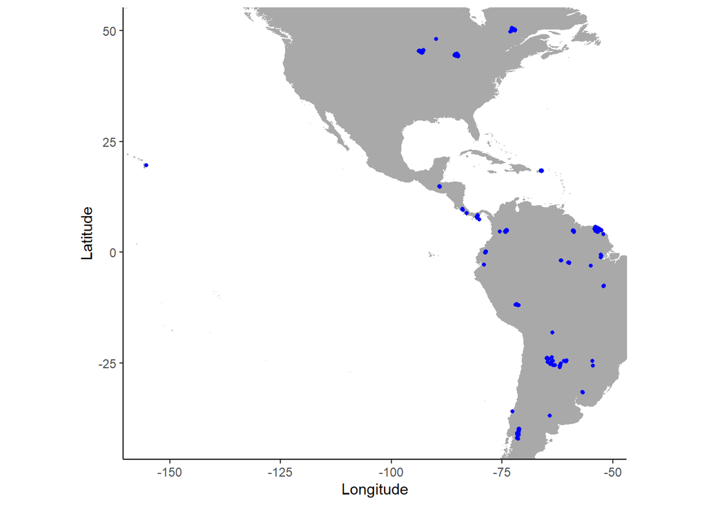

```r
## Load in world map

wm<-map_data("world") %>% filter(region != "Antartica" ) %>% fortify()

## site coords

site_points <- PREDICTS_Aves_Am %>% distinct(SSBS,Longitude,Latitude)

# generate and plot map

site_plot<-ggplot()+ coord_fixed()+
  geom_map(data =wm, map = wm,
           aes(group = group, map_id= region),
           fill = "darkgrey")+
  geom_point(data = fortify(site_points), aes(Longitude, Latitude),
             colour = "blue", size = 1)+
  theme_classic()

plot(site_plot)
```

Because the PREDICTS database is a collation of different studies that often differ in the way data is collected, what is recorded and the sampling effort expended we need to correct for this assuming that the biodiversity metric recorded increases linearly with effort. Additionally, for the diversity metrics that we are going to be calculating records of abundance and occurrence are useful therefore studies that record the species richness of sites are dropped

```r
PREDICTS_Aves_Am <- PREDICTS_Aves_Am %>%


  dplyr::group_by(SS) %>% ## group by study

  dplyr::mutate(Max_Sampling_Effort = max(Sampling_effort)) %>%  # max samplin effort in each site

  dplyr::ungroup() %>%

  dplyr::mutate(Rescaled_Sampling_Effort = Sampling_effort/Max_Sampling_Effort) %>%  ## rescale sampling effort so that the maximum effort with a study is 1

  dplyr::filter(Diversity_metric_type =="Abundance" | Diversity_metric_type ==  "Occurrence") %>%

  dplyr::mutate(Effort_Corrected_Measurement = ifelse(Diversity_metric_is_effort_sensitive == TRUE,
                                                      Measurement/Rescaled_Sampling_Effort,
                                                      Measurement)) %>%

  droplevels()

  ## Now the Biodiversity data is ready to be used

  write_rds(PREDICTS_Aves_Am, "Functional_Intactness_Index/PREDICTS_Americas_Aves.rds")
```

# 1.2 Preparing the data: Traits (GBD)

In addition to biodiversity data to calculate measures of functional diversity information on species functional traits is required. Functional traits are what determines a species functional role in an ecosystem and are informative on the species niche. Functional traits can take a variety of forms such as quantitative traits such as body size, wing length, migratory distance, or qualitative such as foraging strategy, reproductive strategy etc.

In this analysis I will be using measurements of 8 morphometric traits in birds including beak dimensions, wing shape, and tarsus and tail length. To reduce dimensionality, produce major axes of variation and account for the positive association between all traits and body size I will be performing a two-step PCA approach proposed by [Trisos et al. 2014](https://www.journals.uchicago.edu/doi/full/10.1086/678233). To derive independent axes of variation I first partitioned the traits into those related to locomotion (Tarsus, tail, wing) and those related to foraging (beak dimensions) and perform a PCA on each. The first principal component of each will represent the difference in body size and a further PCA on these two axes will produce a single body size axis. The second principal component of each PCA will also be retained to represent meaningful axes of variation in locomotion and foraging strategies.

```r
PCA_Data <- data.frame(PREDICTS_Aves_Am[,c("Jetz_Name", "Bill.TotalCulmen", "Bill.Nares", "Bill.Width", "Bill.Depth", "Tarsus.Length",    "Kipp.s.Distance", "Secondary1", "Wing.Chord", "Hand.Wing.Index", "Tail.Length", "Mass")])

PCA_Data <- distinct(PCA_Data, Jetz_Name, .keep_all = TRUE)


#### Log transform - then standardise and centre for a mean of zero and a standard deviation of 1

PCA_Data <- data.frame(Jetz_Name = PCA_Data[,1], scale(log(PCA_Data[c(2:12)])))

### Perform a PCA on all the traits - This is just used to compare the utility of the Two-step PCA as opposed to just a single full PCA

Full.pca.data <- PCA_Data[,c(2:6,8:9,11)]

Full.pca <- prcomp(Full.pca.data, center = TRUE, scale. = TRUE)

summary(Full.pca)
```

```
## Importance of components:
##                          PC1    PC2     PC3     PC4     PC5     PC6     PC7
## Standard deviation     2.407 1.0519 0.68427 0.59383 0.40556 0.25866 0.17640
## Proportion of Variance 0.724 0.1383 0.05853 0.04408 0.02056 0.00836 0.00389
## Cumulative Proportion  0.724 0.8623 0.92084 0.96492 0.98548 0.99384 0.99773
##                            PC8
## Standard deviation     0.13482
## Proportion of Variance 0.00227
## Cumulative Proportion  1.00000
```

```r
Full.pca
```

```
## Standard deviations (1, .., p=8):
## [1] 2.4066458 1.0519146 0.6842666 0.5938284 0.4055607 0.2586633 0.1763979
## [8] 0.1348184
##
## Rotation (n x k) = (8 x 8):
##                         PC1         PC2         PC3          PC4          PC5
## Bill.TotalCulmen -0.3362972  0.50697634 -0.27469766  0.203903492 -0.007467212
## Bill.Nares       -0.3009422  0.64017030 -0.08111056  0.150943080 -0.114012593
## Bill.Width       -0.3672557 -0.02683642  0.63246086 -0.003088632  0.056421595
## Bill.Depth       -0.3771457 -0.02445697  0.54471742  0.037137766 -0.083233807
## Tarsus.Length    -0.3154672 -0.45893955 -0.28389001  0.618494275 -0.285766314
## Secondary1       -0.3847228 -0.31316850 -0.12043174  0.069445980  0.150832905
## Wing.Chord       -0.3795583 -0.09861607 -0.26621865 -0.271108716  0.742775709
## Tail.Length      -0.3572488 -0.11581664 -0.23509306 -0.688035573 -0.566308575
##                          PC6          PC7         PC8
## Bill.TotalCulmen  0.15306989  0.081931129  0.69472647
## Bill.Nares       -0.09150744 -0.002525241 -0.66998073
## Bill.Width        0.66555147 -0.129629549 -0.03795771
## Bill.Depth       -0.71472144 -0.034117891  0.20036990
## Tarsus.Length     0.02744651 -0.372033471 -0.07682205
## Secondary1        0.03194695  0.833114422 -0.12936974
## Wing.Chord       -0.10013854 -0.368793590 -0.06392108
## Tail.Length       0.05107701 -0.082557906  0.01296166
```

```r
### PCA on the Foraging traits - Beak Dimensions

For.pca.data <- PCA_Data[,c(2:5)]

For.pca <- prcomp(For.pca.data, center = TRUE, scale. = TRUE)
For.pca
```

```
## Standard deviations (1, .., p=4):
## [1] 1.7860728 0.8368969 0.2610474 0.2034741
##
## Rotation (n x k) = (4 x 4):
##                         PC1        PC2         PC3         PC4
## Bill.TotalCulmen -0.5069916 -0.4753095  0.12033221 -0.70891506
## Bill.Nares       -0.4981140 -0.5185408 -0.07930935  0.69044032
## Bill.Width       -0.4928418  0.5244964  0.68434638  0.11696375
## Bill.Depth       -0.5019452  0.4796871 -0.71477284 -0.08397069
```

```r
summary(For.pca)
```

```
## Importance of components:
##                           PC1    PC2     PC3     PC4
## Standard deviation     1.7861 0.8369 0.26105 0.20347
## Proportion of Variance 0.7975 0.1751 0.01704 0.01035
## Cumulative Proportion  0.7975 0.9726 0.98965 1.00000
```

```r
### PCA on the Locomotory traits - Tarsus, tail and wing dimensions

Loco.pca.data <- PCA_Data[,c(6,8,9,11)]

Loco.pca <- prcomp(Loco.pca.data, center = TRUE, scale. = TRUE)
Loco.pca
```

```
## Standard deviations (1, .., p=4):
## [1] 1.8356041 0.6466645 0.4141425 0.2021596
##
## Rotation (n x k) = (4 x 4):
##                     PC1        PC2        PC3        PC4
## Tarsus.Length 0.4719598 -0.7467380  0.2365757 -0.4045593
## Secondary1    0.5337495 -0.1501405 -0.1342265  0.8213115
## Wing.Chord    0.5078412  0.3084822 -0.7041538 -0.3887202
## Tail.Length   0.4842135  0.5698060  0.6558831 -0.1033236
```

```r
summary(Loco.pca)
```

```
## Importance of components:
##                           PC1    PC2     PC3     PC4
## Standard deviation     1.8356 0.6467 0.41414 0.20216
## Proportion of Variance 0.8424 0.1045 0.04288 0.01022
## Cumulative Proportion  0.8424 0.9469 0.98978 1.00000
```

```r
#### Final PCA on the first Principal component of each of the first PCAs to derive an axis of body size

Body.pca.data <- data.frame(LocoPC1 = Loco.pca$x[,1], ForPC1 = For.pca$x[,1])
Body.pca <- prcomp(Body.pca.data, center = TRUE, scale. = TRUE)

Body.pca
```

```
## Standard deviations (1, .., p=2):
## [1] 1.3260335 0.4915641
##
## Rotation (n x k) = (2 x 2):
##                PC1       PC2
## LocoPC1  0.7071068 0.7071068
## ForPC1  -0.7071068 0.7071068
```

```r
summary(Body.pca)
```

```
## Importance of components:
##                           PC1    PC2
## Standard deviation     1.3260 0.4916
## Proportion of Variance 0.8792 0.1208
## Cumulative Proportion  0.8792 1.0000
```

```r
### Match the independent axes of trait variation to species in PREDICTS

PC_Scores <- data.frame(Jetz_Name = PCA_Data[,1], Foraging.PCA = For.pca$x[,2], Loco.PCA = Loco.pca$x[,2], Body.PCA = Body.pca$x[,1])


### standardize the PC scores so that the maximum value is 1

for(col in colnames(PC_Scores[,-1])){
  PC_Scores[,col] <- PC_Scores[,col]/max(PC_Scores[,col])
}


write_rds(file = "Functional_Intactness_Index/PC_Scores.rds", PC_Scores)
```

# 2.1 Calculation of functional metrics: Functional Diversity (Rao’s Quadratic Entropy)

The measure of functional diversity I am going to be using is Rao’s Quadratic entropy (Rao’s Q). Rao’s Q is calculated as the sum of pairwise functional distances between species within a assembalage, weighted by each species abundance. Rao’s Q had been widely used in the literature and has advantages by being able to account for species relative abundance, a limitation of a number of other measures of functional diversity. There are a number of ways to calculate functional distances between species within a community but I will be considering two common methods. I will be calculating each measure of Rao in the **FD** and **SYNCSA** packages respectively.

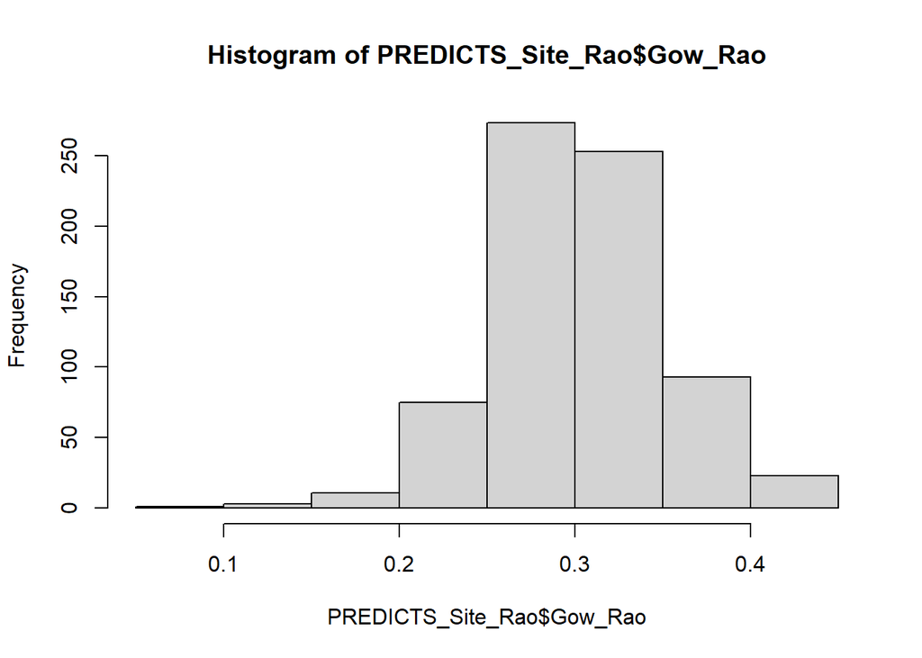

```r
#######################################
#### Functional Diversity of sites ####
#######################################

abundance_data <- PREDICTS_Aves_Am %>% dplyr::filter(Diversity_metric == "abundance") %>% dplyr::filter(Effort_Corrected_Measurement != 0) %>%

  ### filter out studies of just a single species

  dplyr::group_by(SS) %>% dplyr::mutate(study_n_species = n_distinct(Jetz_Name)) %>% dplyr::filter(study_n_species > 1) %>% ungroup() %>%

  #### group by Site and Species get abundance if there are some sites that the same species is recorded multiple times
  dplyr::group_by(SSBS,Jetz_Name) %>% dplyr::mutate(SpeciesSiteAbundance = sum(Effort_Corrected_Measurement), n_spp = n()) %>%

  filter(!duplicated(n_spp) | n_spp == 1) %>%

  ungroup() %>%   droplevels() %>%

  ### group by just site to get Total site abundance
  group_by(SSBS) %>% dplyr::mutate(TotalSiteAbundance = sum(SpeciesSiteAbundance), site_species = n_distinct(Jetz_Name)) %>%

  ungroup() %>%

  ### relative abundance of each species at each site SpeciesSitelevel abundance/TotalSite abundance
  dplyr::mutate(RelativeAbundance = SpeciesSiteAbundance/TotalSiteAbundance) %>%

  droplevels()


## save the abundance data that will come in use for the modelling

write_rds(abundance_data, file = "Functional_Intactness_Index/abundance_data.rds")


#####################################################
#### Function to calculate Rao's Q for each site ####
####################################################

#### Rao's Q is based on the sum of pairwise dissimilarities in functional traits between species within a community and there are methods based on gower distances of mean trait values or you can calculate the dissimilarity as the non-overlapping area in multidimensional trait space so lets give it a go


Rao_Q_Func <- function(data){

  ### get the list of uncique species across teh whole dataset

Species_abundance <- data.frame(data) %>% dplyr::distinct(Jetz_Name) %>% droplevels()

### loop over every site in the dataset to collate the relative abundance of each species

for(site in levels(data$SSBS)){

  Spp_abd <- data %>% filter(SSBS == site) %>% droplevels() %>% data.frame()


  ### Join species withining site to dataframe and rename column as site name

  Species_abundance <- Species_abundance %>% left_join(Spp_abd[,c("Jetz_Name", "RelativeAbundance")], by = "Jetz_Name")
  colnames(Species_abundance)[which(colnames(Species_abundance) == "RelativeAbundance")] <- paste(site)
}

## rename rows as species and drop column from dataset

rownames(Species_abundance) <- Species_abundance$Jetz_Name
Species_abundance <- as.matrix(Species_abundance[,-1])

## Nas to zeros

Species_abundance[is.na(Species_abundance)] <- 0

### Join all species in datasets traits scores

traits <- data.frame(data) %>% dplyr::distinct(Jetz_Name) %>% droplevels() %>% left_join(PC_Scores, by = "Jetz_Name")
rownames(traits) <- traits$Jetz_Name
traits <- traits[,-1]



Rao_Gow <- rao.diversity(comm = t(Species_abundance),traits =  traits)    #THIS is using the package SYNCSA that calcuates Rao's using gowdis


Rao_Var <- FD::dbFD(x = traits, a = t(Species_abundance), scale.RaoQ = TRUE) ## dbFD calculates Rao's Q as a measure of variance
Rao <- data.frame(Var = as.numeric(Rao_Var$RaoQ), Gow = Rao_Gow$FunRao)



return(Rao)
}



PREDICTS_Site_Rao <- data.frame(abundance_data) %>% distinct(SSBS, .keep_all = TRUE)%>% dplyr::select(SS, SSB, SSBS,UN_subregion, LandUse, Use_intensity, LandUse_Intensity, Longitude,Latitude, site_species)

PREDICTS_Site_Rao$SSBS <- as.character(PREDICTS_Site_Rao$SSBS)
PREDICTS_Site_Rao$Gow_Rao <- NA
PREDICTS_Site_Rao$Var_Rao <- NA


Rao_data <- Rao_Q_Func(abundance_data)

PREDICTS_Site_Rao$Gow_Rao <- Rao_data$Gow
PREDICTS_Site_Rao$Var_Rao <- Rao_data$Var

hist(PREDICTS_Site_Rao$Gow_Rao)
```

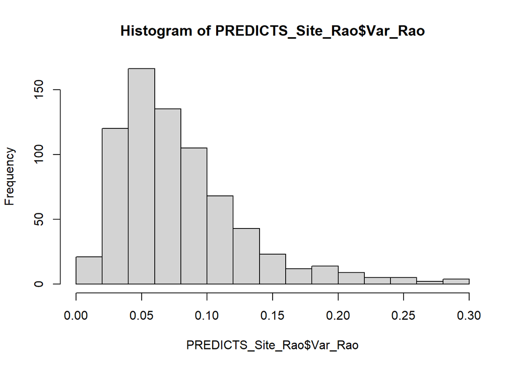

```r
hist(PREDICTS_Site_Rao$Var_Rao)
```

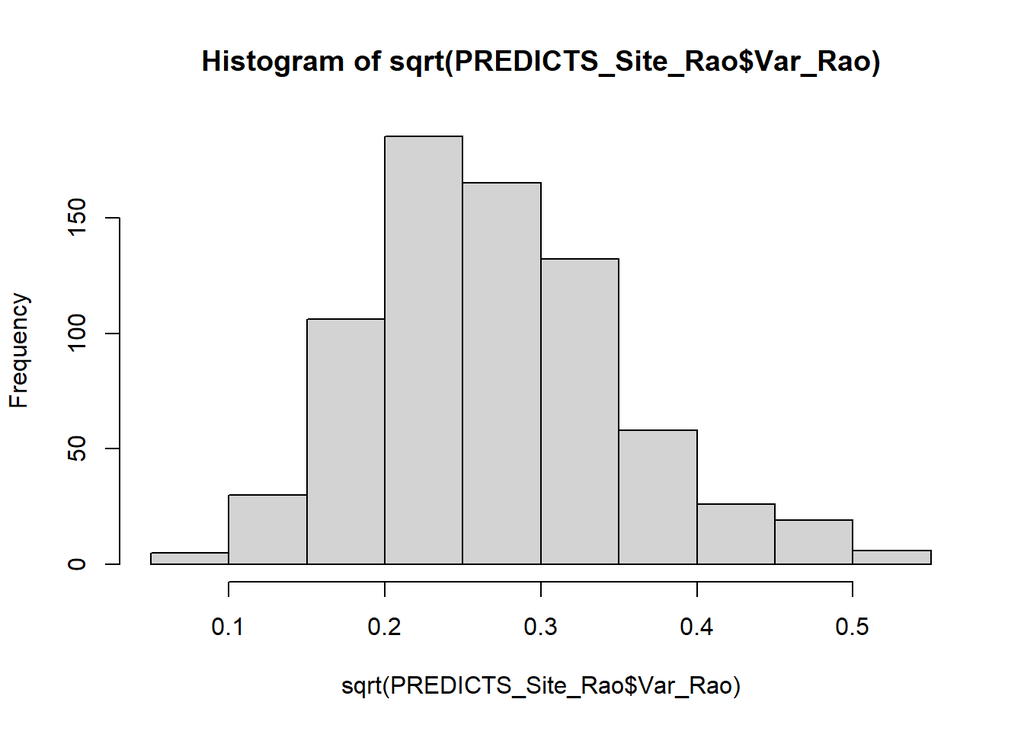

```r
hist(sqrt(PREDICTS_Site_Rao$Var_Rao))
```

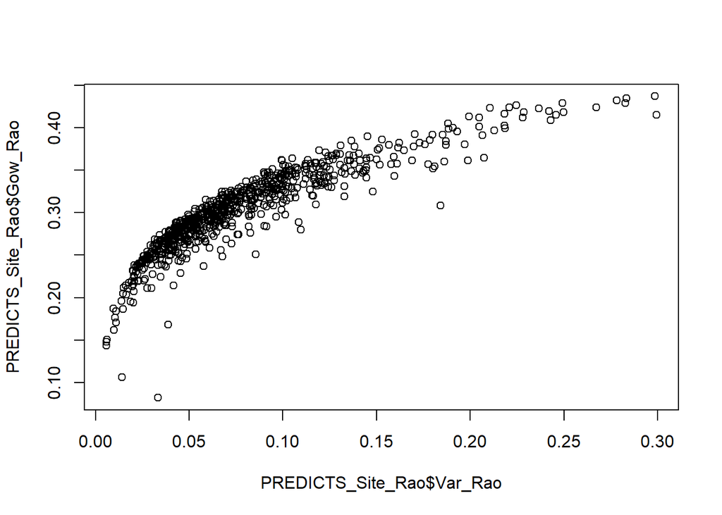

```r
plot(PREDICTS_Site_Rao$Gow_Rao ~ PREDICTS_Site_Rao$Var_Rao)
```

```r
#write_rds(PREDICTS_Site_Rao, file = "Functional_Intactness_Index/PREDICTS_Site_Rao.rds")
```

We can see that he measures of Rao’s Q are related to each other no matter how you calculate it and variance based Rao’s being poisitve skewed that a square root or cube root transformation normalizes.

# 2.2 Calculation of functional metric: Function similarity

The second metric I am going to calculate is functional similarity measured as the overlap of hypervolumes in multidimensional trait space. Essentially we want to know how much functional overlap there is between Primary minimal sites and sites of other land-use types and intensities. As previously mentioned the overlap of hypervolumes is not a full measure of beta-diversity as it only considers the proportion of function that is retain between the two sites and not the changes that occur beyond those bounds, which may be substantial. Some additional analyses would look more closely at this change in functional structure as a result of environmental change by partitioning beta-diversity into nestedness (differences due to shrinking of function) and turnover( differences due to replacement), each with different conservation requirements, but I digress.

Hypervolumes in multidimensional space are defined by the species that occur at each site that their associated trait scores, here in three dimensions relating to the PC axes of body, foraging and locomotion traits. I will construct the hypervolumes using the *hypervolume* package developed by [B. Blonder](http://www.benjaminblonder.org/papers/2014_GEB.pdf), and in two different ways. First I will create a minimum convex hull that incorporates all points, however this has some downfalls as it assumes that all space between points is occupied no matter how disparate they are and can lead to overestimation of hypervolume size and inaccuracies in overlap calculation. Therefore, secondly, I will be using a more restrictive decision based algorithm to construct the hypervolume called a *One-Class Support Vector Machine* which randomly generates points in multidimensional trait space and decides whether it is “in” or “out” of the boundaries of the hypervolume with enough samples the points define the hypervolume in trait space.

To accurately calculate the hypervolumes and their overlap I have only included sites that have greater that 21 records of species occurrence or abundance.

```r
#############################################
#### Functional Similarity between sites ####
#############################################


Similarity_data <- data.frame(PREDICTS_Aves_Am) %>% left_join(PC_Scores, by = "Jetz_Name") %>% filter(Effort_Corrected_Measurement > 0) %>%

   ### calculating a hypervolume in 3 dimensions with fewer than 21 species on result in inaccurcies
  group_by(SSBS) %>% dplyr::mutate(Site_spp = n_distinct(Jetz_Name)) %>% filter(Site_spp > 21) %>% ungroup() %>%

  ## how many studies have at least one site of primary minimal for comparisons to be made and make sure the sites have more than a single site.

  group_by(SS) %>% dplyr::mutate(n_primary_min = sum(LandUse_Intensity == "Primary_Minimal use" ), n_sites_within_studies = n_distinct(SSBS)) %>%


  ungroup() %>% filter(n_primary_min > 0 ) %>%  filter(n_sites_within_studies > 1) %>%

  droplevels() %>%

  data.frame()

write_rds(Similarity_data, file = "Functional_Intactness_Index/similarity_data.rds")




########################################################
###### Loop to generate functional overlap of sites ####
########################################################

### With studies with multiple pri-min sites it compares with each other twice -- prim1 v prim2 & prim2 v prim 1 etc etc should only really compare once therefore i have create a function that will remove the duplicated comparisons.

remove_dupl_comparisons <- function(data){

  data$drop <- NA
  data$comparison <- paste(data$site1,data$site2, sep = "_")
  data[1,"drop"] <- FALSE



  for(i in 2:NROW(data)){

    site1 <- data[i,"site1"]
    site2 <- data[i,"site2"]

    match_1 <- as.numeric(grep(data[1:i-1,"comparison"], pattern = site1))
    match_2 <- as.numeric(grep(data[1:i-1,"comparison"], pattern = site2))

    if(any(match_1 %in% match_2)){
      data[i,"drop"] <- TRUE
    } else {
      data[i,"drop"] <- FALSE
    }

  }

  if(any(data$drop)){
  data <- data[-which(data$drop == TRUE & data$Contrast == "Primary_Minimal use-Primary_Minimal use"),-which(colnames(data) == "comparison" | colnames(data) == "drop")]
  }


  return(data)
}


### What studies do we have in the dataset

studies <- levels(Similarity_data$SS)

#### empty data frame for results to go into





registerDoParallel(cores = 4)

Overlap_data <- foreach(study = studies,
                         .combine = "rbind",
                         .packages = c("hypervolume","betapart","tidyverse","magrittr","geosphere","gower","raster")) %dopar% {


  ### data for study
Overlap_data <- c()



  data <- Similarity_data %>% filter(SS == study) %>% droplevels()

  ### coordinates going to be used to calculate distance between sites

  LatLong <- data.frame(data) %>% distinct(SSBS,Latitude,Longitude)

  ### land use and intensity at each site

  LandUse <- data.frame(data) %>% distinct(SSBS, LandUse_Intensity)

  ### which sites are of primary minimal landuse type and intensity

  Primary_sites <- LandUse %>% filter(LandUse_Intensity == "Primary_Minimal use") %>% pull(SSBS) %>% as.character()

  #### all other sites

  all_sites <- LandUse %>% pull(SSBS) %>% as.character()




  ###### get the comparisons with the primary minimal site and all other sites within the study

  site_comparisons <- expand.grid(Primary_sites, all_sites) %>%
    dplyr::rename(site1 = Var1, site2 = Var2) %>% dplyr::mutate(site1 = as.character(site1), site2 = as.character(site2)) %>%
    filter(site1 != site2) %>%
    left_join(LatLong, by = c("site1" = "SSBS")) %>% dplyr::rename(site1Lat = Latitude, site1Long = Longitude) %>%
    left_join(LatLong, by = c("site2" = "SSBS")) %>% dplyr::rename(site2Lat = Latitude, site2Long = Longitude) %>%
    left_join(LandUse, by = c("site1" = "SSBS")) %>% dplyr::rename(site1LUI = LandUse_Intensity) %>%
    left_join(LandUse, by = c("site2" = "SSBS")) %>% dplyr::rename(site2LUI = LandUse_Intensity) %>%
    dplyr::left_join(distinct(Similarity_data[,c("SSBS","Site_spp")]), by = c("site1" = "SSBS")) %>%
    dplyr::rename(site1_spp = Site_spp) %>%
    left_join(distinct(Similarity_data[,c("SSBS","Site_spp")]), by = c("site2" = "SSBS")) %>%
    dplyr::rename(site2_spp = Site_spp) %>%
    dplyr::mutate(Contrast = paste(site1LUI,site2LUI, sep = "-"))


  site_comparisons <- remove_dupl_comparisons(site_comparisons)


  ### calculate geographic distance between the sites

  site_one <- as.matrix(site_comparisons[,c("site1Long", "site1Lat")])
  site_two <- as.matrix(site_comparisons[,c("site2Long", "site2Lat")])

  dist <- data.frame(distHaversine(site_one,site_two))

## Collate together the variables for the dataset

  study_data <- site_comparisons %>% dplyr::select(site1,site2, Contrast, site1Long, site1Lat, site2Long,site2Lat, site1_spp, site2_spp)
  study_data$min_site_spp <- ifelse(study_data$site1_spp > study_data$site2_spp, study_data$site2_spp, study_data$site1_spp)
  study_data <- cbind(study_data, distance = dist[,1])
  study_data$SS <- study
  study_data$convex_overlap <- NA
  study_data$hyper_overlap <- NA


  ### Also want to add in a variable for the minimum number of species in either of the sites used to construct the hypervolumes. This will be used as weights in the models as there may be greater uncertainty in the hypervolume overlaps when fewer species have been recorded at either site.


    for(i in 1:NROW(site_comparisons)){

      i <- 1
      ##### get the species in both sites being compared

      site1 <- site_comparisons[i,"site1"]
      site1_spp <- Similarity_data %>% filter(SSBS == site1) %>% distinct(Jetz_Name, .keep_all = FALSE)


      ### join the traits and drop species names

      site1_data <- site1_spp %>% left_join(PC_Scores, by = "Jetz_Name")
      rownames(site1_data) <- site1_data$Jetz_Name
      site1_data <- as.matrix(site1_data[,-1])


      ### calculate support vector machine and minimum convex hull hypervolumes

      hypersvm_1 <- hypervolume(site1_data, method = "svm")
      convex_1 <- expectation_convex(site1_data, check.memory = FALSE)


      ### site 2

      site2 <- site_comparisons[i,"site2"]
      site2_spp <- Similarity_data %>% filter(SSBS == site2) %>% distinct(Jetz_Name, .keep_all = FALSE)

      site2_data <- site2_spp %>% left_join(PC_Scores, by = "Jetz_Name")
      rownames(site2_data) <- site2_data$Jetz_Name
      site2_data <- as.matrix(site2_data[,-1])

      hypersvm_2 <- hypervolume(site2_data, method = "svm")
      convex_2 <- expectation_convex(site2_data, check.memory = FALSE)

      svm_list <- hypervolume_set(hypersvm_1,hypersvm_2, check.memory = FALSE)
      convex_list <- hypervolume_set(convex_1, convex_2, check.memory = FALSE)

      svm_overlap <- hypervolume_overlap_statistics(svm_list)
      convex_overlap <- hypervolume_overlap_statistics(convex_list)

      study_data[i,"hyper_overlap"] <- svm_overlap[1]
      study_data[i,"convex_overlap"] <- convex_overlap[1]

    }

  Overlap_data <- rbind(Overlap_data,study_data)


                         }



write_rds(file = "Functional_Intactness_Index/Functional_Overlap_data.rds", Overlap_data)


registerDoSEQ()
```

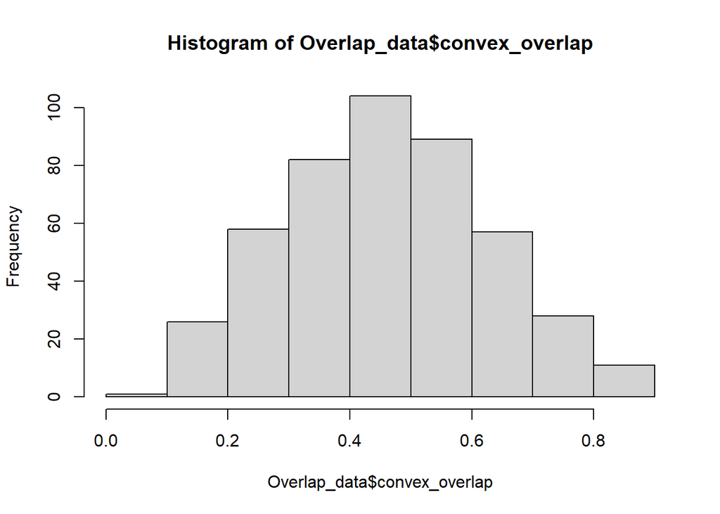

```r
Overlap_data <- readRDS("Functional_Intactness_Index/Functional_Overlap_data.rds")

hist(Overlap_data$convex_overlap)
```

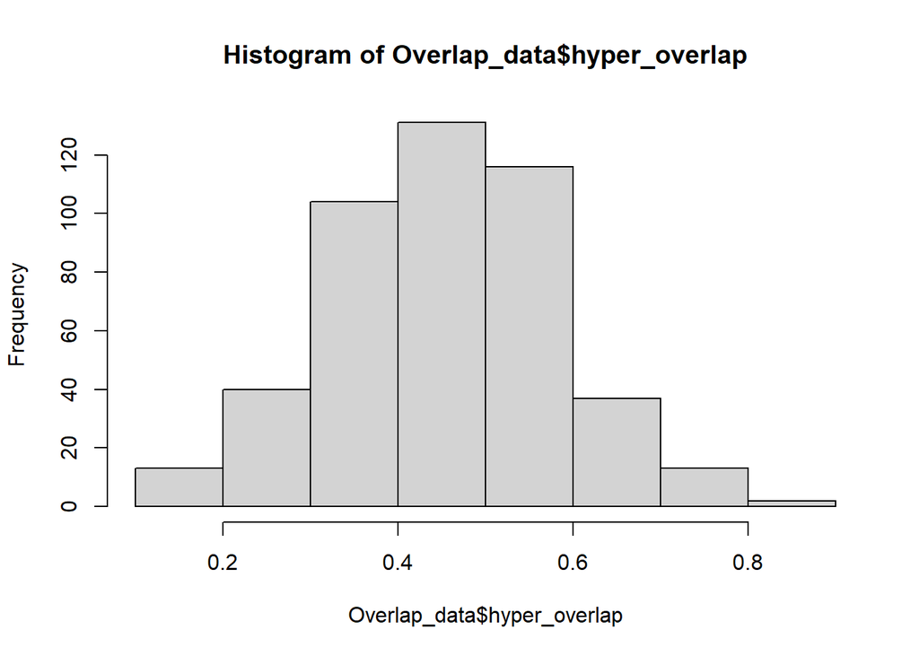

```r
hist(Overlap_data$hyper_overlap)
```

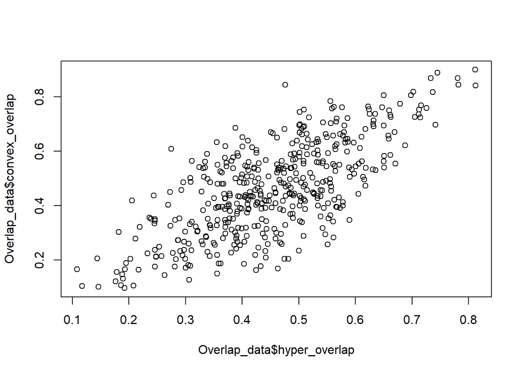

```r
plot(Overlap_data$convex_overlap ~ Overlap_data$hyper_overlap)
```

Can see that similarity scores are again very related to each other regardless of hypervolume method used and the scores are normally distributed.

# 3 Other related pressures

Now that we have the metrics for functional diversity and similarity/overlap calculated we are almost ready to get on with modelling how these metrics are impacted by land-use change, however there are going to be many other pressures that may effect the observed functional diversity and similarity of a site, therefore we must consider other factors. Here I calculate the other pressures for each of the models.

Functional Diversity: Human Population density and density of roads at 1km and 50km radius

Functional Similarity: Human population density, density of road at 1km and 50 km radius, geographic distance between sites (already calculated in the previous loop), environmental distance between sites. The pressure included in the models will be the pressure experienced at site2 and the difference in pressure between the two sites.

## 3.1 Human population density

```r
PREDICTS_Site_Rao <- readRDS("Functional_Intactness_Index/PREDICTS_Site_Rao.rds")
Overlap_data <- readRDS("Functional_Intactness_Index/Functional_Overlap_data.rds")



hpd <- raster("Datasets/PREDICTS_variables/gpw_v4_population_density_adjusted_to_2015_unwpp_country_totals_rev11_2015_2pt5_min.tif")


### calculate human population density for Functional diversity sites

hpd_values <- raster::extract(hpd,PREDICTS_Site_Rao[,c("Longitude","Latitude")])

## human population density trandformed with the log +1 transformation
PREDICTS_Site_Rao$logHPD <- log(hpd_values + 1)



### calculate for functional similarity/overlap data

hpd_values_site1 <- raster::extract(hpd,Overlap_data[,c("site1Long","site1Lat")])
hpd_values_site2 <- raster::extract(hpd,Overlap_data[,c("site2Long","site2Lat")])

Overlap_data$S1logHPD <- log(hpd_values_site1 + 1)
Overlap_data$S2logHPD <- log(hpd_values_site2 + 1)

Overlap_data$logHPDdiff <- Overlap_data$S2logHPD - Overlap_data$S1logHPD
```

## 3.2 Environmental distance

```r
Bioclim_5 <- raster("Datasets/Environmental_Variables/wc2.1_30s_bio_5.tif")
Bioclim_6 <- raster("Datasets/Environmental_Variables/wc2.1_30s_bio_6.tif")
Bioclim_13 <- raster("Datasets/Environmental_Variables/wc2.1_30s_bio_13.tif")
Bioclim_14 <- raster("Datasets/Environmental_Variables/wc2.1_30s_bio_14.tif")
Elevation <- raster("Datasets/Environmental_Variables/wc2.1_30s_elev.tif")


### we only have to calculate the environmental distance when comparing two sites.

site_one <- as.matrix(Overlap_data[,c("site1Long","site1Lat")])
site_two <- as.matrix(Overlap_data[,c("site2Long","site2Lat")])

environ_1 <- data.frame(Ele  = raster::extract(Elevation,site_one), B5 = raster::extract(Bioclim_5,site_one), B6 = raster::extract(Bioclim_6, site_one),
                        B13 = raster::extract(Bioclim_13, site_one), B14 = raster::extract(Bioclim_14, site_one))

environ_2 <- data.frame(Ele  = raster::extract(Elevation,site_two), B5 = raster::extract(Bioclim_5,site_two), B6 = raster::extract(Bioclim_6, site_two),
                        B13 = raster::extract(Bioclim_13, site_two), B14 = raster::extract(Bioclim_14, site_two))


## calculate the gowers distance between environmental variables

environ_dist <- gower_dist(x = environ_1, y = environ_2)
#### I dont know how to best transform it now so Im just going to keep it as is

Overlap_data$env_distance <- environ_dist
```

## 3.3 Density of Roads

```r
### load in the roads shape file for the americas
Roads <- st_read("Datasets/PREDICTS_variables/groads-v1-americas-shp/groads-v1-americas-shp/gROADS-v1-americas.shp")
### combine into a single shapefile
Roads <- st_combine(Roads)
### transform to be projected on the mercator projection that deals in meters rather than latlong
Roads <- st_transform(Roads, crs = "+proj=merc +ellps=WGS84 +datum=WGS84 +units=m +no_defs")

## Both datasets are going to need information on road densities and will be some overlap of sites so make a vector of all unique sites across both datasets

sites <- unique(c(Overlap_data$site1,Overlap_data$site2,PREDICTS_Site_Rao$SSBS))

road_densities <- c()

registerDoParallel(cores = 4)


road_densities <- foreach(site = sites,
                          .combine = "rbind",
                          .packages = c("tidyverse", "sf", "rgeos", "lwgeom")) %dopar%{


  site_LongLat <- PREDICTS_Aves_Am %>% filter(SSBS %in% site) %>% distinct(SSBS,Longitude,Latitude)


  point <- as.matrix(site_LongLat[,c("Longitude","Latitude")])

  point <- st_point(point)
  point <- st_sfc(point)

  ### first crs needs to be in longlat format as the points are coordinates then transformed into a meters based projection such as mercator to calculate distance in km

  st_crs(point) <- "+proj=longlat +datum=WGS84 +no_defs"
  point <- st_transform(point, crs = "+proj=merc +ellps=WGS84 +datum=WGS84 +units=m +no_defs")

  ## 1k and 50k radius around points

  buffer_1km <- st_buffer(point, 1000)
  buffer_50km <- st_buffer(point, 50000)


  ## overlap buffer with roads shape file to just get roads within each radius

  intersect_1km <- st_intersection(Roads, buffer_1km)

  #### if there are any roads caluclate the density as length of roads/area of radius

  if(length(intersect_1km) != 0 ){
    density_1km <- (st_length(intersect_1km)/1000)/(st_area(buffer_1km)/1000000)
  } else {
    density_1km <- 0
  }

  intersect_50km <- st_intersection(Roads, buffer_50km)

  if(length(intersect_50km) != 0) {
    density_50km <- (st_length(intersect_50km)/1000)/(st_area(buffer_50km)/1000000)
  } else {
    density_50km <- 0
  }


  densities <- data.frame(site = paste(site), density_1km = as.numeric(density_1km), density_50km = as.numeric(density_50km))

                          }

registerDoSEQ()

## simply join road densities to functional diversity dataset

PREDICTS_Site_Rao <- PREDICTS_Site_Rao %>% dplyr::left_join(road_densities, by = c("SSBS" = "site"))

### join to similarity dataset and calculate difference in density of roads

Overlap_data <- Overlap_data %>%
  dplyr::left_join(road_densities, by = c("site1" = "site")) %>%
  dplyr::rename(S1RD1K = density_1km, S1RD50K = density_50km) %>%
  dplyr::left_join(road_densities, by = c("site2" = "site")) %>%
  dplyr::rename(S2RD1K = density_1km, S2RD50K = density_50km)


Overlap_data$RD1Kdiff <- Overlap_data$S2RD1K - Overlap_data$S1RD1K
Overlap_data$RD50Kdiff <- Overlap_data$S2RD50K - Overlap_data$S1RD50K

write_rds(file = "Datasets/PREDICTS_variables/Road_densities1_and_50k.rds", road_densities)
```

# Save the datasets

```r
write_rds(file = "Functional_Intactness_Index/Functional_Overlap_data.rds", Overlap_data)
write_rds(file = "Functional_Intactness_Index/PREDICTS_Site_Rao.rds", PREDICTS_Site_Rao)
```